# Outlier Detection, Descriptive Statistics, Graphs & Association Tests

**Input:** `Students_Performance_CLEANED.xlsx` (output of the data-cleaning notebook)

**Covers (per the planned workflow):**

1. Import clean dataset
2. Outlier Detection (boxplots, before/after)
3. Descriptive Statistics
4. Frequency Tables
5. Graphs (histograms, bar charts, scatter plots, Q-Q plots)
6. Association Tests (Chi-square, Kruskal-Wallis)
7. Export outlier-checked dataset

All plots are also saved as `.jpg` files in the working folder.

## Step 1: Import Clean Dataset

```python
import pandas as pd
import numpy as np
import matplotlib.pyplot as plt
import seaborn as sns
from scipy import stats

FILE_PATH = r"C:\Users\kpriy\Downloads\Students_Performance_CLEANED.xlsx"
df = pd.read_excel(FILE_PATH)

# CGPA_Class should be treated as an ordered category throughout this notebook
class_order = ["General", "2nd Lower", "2nd Upper", "1st Class"]
df["CGPA_Class"] = pd.Categorical(df["CGPA_Class"], categories=class_order, ordered=True)

print("Shape:", df.shape)
df.head()
```

```
Shape: (1168, 31)
```

|  | Admission_Year | Gender | Age | HSC_Year | Semester | Scholarship | Uses_Transport | Study_Hours | Study_Sessions | Learning_Mode | ... | Relationship_Status | Co_Curricular | Living_With | Health_Issues | Previous_SGPA | Physical_Disability | Current_CGPA | Credits_Completed | Family_Income | CGPA_Class |
| --- | --- | --- | --- | --- | --- | --- | --- | --- | --- | --- | --- | --- | --- | --- | --- | --- | --- | --- | --- | --- | --- |
| 0 | 2018 | Male | 24 | 2016 | 12 | Yes | No | 3 | 2 | Offline | ... | Single | Yes | Bachelor | No | 2.68 | No | 3.15 | 75 | 25000 | 2nd Lower |
| 1 | 2021 | Male | 22 | 2020 | 4 | Yes | Yes | 3 | 2 | Online | ... | Single | Yes | Family | No | 2.68 | No | 3.15 | 36 | 100000 | 2nd Lower |
| 2 | 2020 | Female | 21 | 2019 | 5 | No | No | 3 | 3 | Offline | ... | Single | No | Bachelor | No | 2.68 | No | 3.15 | 50 | 50000 | 2nd Lower |
| 3 | 2021 | Male | 20 | 2020 | 4 | Yes | No | 1 | 3 | Offline | ... | Single | No | Bachelor | Yes | 2.68 | No | 3.15 | 36 | 62488 | 2nd Lower |
| 4 | 2021 | Male | 22 | 2019 | 4 | Yes | No | 3 | 1 | Online | ... | Relationship | No | Bachelor | Yes | 2.68 | No | 3.15 | 36 | 50000 | 2nd Lower |

5 rows × 31 columns

## Step 2: Outlier Detection

**Approach used in this notebook (matching standard statistical practice):** the 1.5×IQR rule is used only to *flag candidate* points for inspection where it is not used to automatically delete anything. For each flagged variable, we look at how the flagged values are distributed:

- If many responses sit beyond the whisker (a genuine **bulk region**, e.g. a cluster of 30+ students with similar values), that's a real feature of the population, not an error, and is **kept**.
- If a value is an **isolated, single point**, clearly separated from every other observation, *and* it is domain-implausible (not just statistically rare), it is treated as a likely data-entry error and **removed**.

The final keep/remove decision for each flagged variable is discussed after the "before" boxplots below.

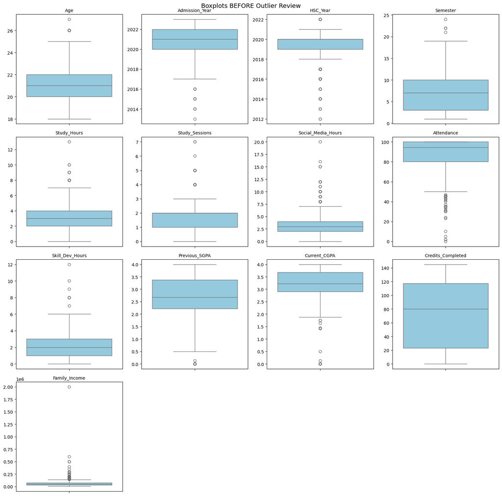

```python
numeric_cols = [
    "Age", "Admission_Year", "HSC_Year", "Semester", "Study_Hours", "Study_Sessions",
    "Social_Media_Hours", "Attendance", "Skill_Dev_Hours", "Previous_SGPA", "Current_CGPA",
    "Credits_Completed", "Family_Income",
]

def plot_boxplots(data, cols, title, filename):
    n = len(cols)
    n_cols = 4
    n_rows = int(np.ceil(n / n_cols))
    fig, axes = plt.subplots(n_rows, n_cols, figsize=(4 * n_cols, 4 * n_rows))
    axes = axes.flatten()
    for i, col in enumerate(cols):
        sns.boxplot(y=data[col], ax=axes[i], color="skyblue")
        axes[i].set_title(col, fontsize=10)
        axes[i].set_ylabel("")
    for j in range(len(cols), len(axes)):
        fig.delaxes(axes[j])
    fig.suptitle(title, fontsize=14)
    fig.tight_layout()
    plt.savefig(filename, dpi=200, bbox_inches="tight")
    plt.show()

plot_boxplots(df, numeric_cols, "Boxplots BEFORE Outlier Review", "boxplots_before.jpg")
```

```python
# Systematically flag candidate outliers with the 1.5xIQR rule, and show HOW they're distributed
# (a handful of values repeated many times = bulk region; a single unique value = isolated point)
for col in numeric_cols:
    q1, q3 = df[col].quantile(0.25), df[col].quantile(0.75)
    iqr = q3 - q1
    lo, hi = q1 - 1.5 * iqr, q3 + 1.5 * iqr
    flagged = df[(df[col] < lo) | (df[col] > hi)][col]
    print(f"--- {col} --- IQR whiskers: [{lo:.2f}, {hi:.2f}]  |  flagged points: {len(flagged)}")
    print(flagged.value_counts().sort_index())
    print()
```

```
--- Age --- IQR whiskers: [17.00, 25.00]  |  flagged points: 13
Age
26    12
27     1
Name: count, dtype: int64

--- Admission_Year --- IQR whiskers: [2017.00, 2025.00]  |  flagged points: 13
Admission_Year
2013    1
2014    3
2015    5
2016    4
Name: count, dtype: int64

--- HSC_Year --- IQR whiskers: [2017.50, 2021.50]  |  flagged points: 123
HSC_Year
2012     2
2013     3
2014    10
2015     5
2016    27
2017    67
2022     9
Name: count, dtype: int64

--- Semester --- IQR whiskers: [-7.50, 20.50]  |  flagged points: 5
Semester
21    1
22    3
24    1
Name: count, dtype: int64

--- Study_Hours --- IQR whiskers: [-1.00, 7.00]  |  flagged points: 22
Study_Hours
8     15
9      4
10     2
13     1
Name: count, dtype: int64

```

[output cut: 84 more lines]

```
180000      1
190000      2
200000     12
210000      1
235000      1
250000      4
255000      1
277000      1
300000      4
350000      1
400000      1
500000      3
600000      1
2000000     1
Name: count, dtype: int64
```

**Decisions, variable by variable:**

[output not shown]

**Net result: two rows are removed** - the single Social_Media_Hours = 20 entry, and the single Family_Income = 2,000,000 entry.

```python
# Remove the two confirmed outliers:
# 1) Social_Media_Hours = 20 (isolated, practically impossible value)
# 2) Family_Income = 2,000,000 (isolated extreme value, far beyond the next-highest income of
#    600,000; plausible on its own, but removed so the model generalises rather than being
#    pulled by a single extreme case)
before_n = len(df)
df = df[(df["Social_Media_Hours"] != 20) & (df["Family_Income"] != 2000000)].copy()
after_n = len(df)

print(f"Rows removed: {before_n - after_n}")
print(f"Shape before: {before_n} rows -> after: {after_n} rows")
```

```
Rows removed: 2
Shape before: 1168 rows -> after: 1166 rows
```

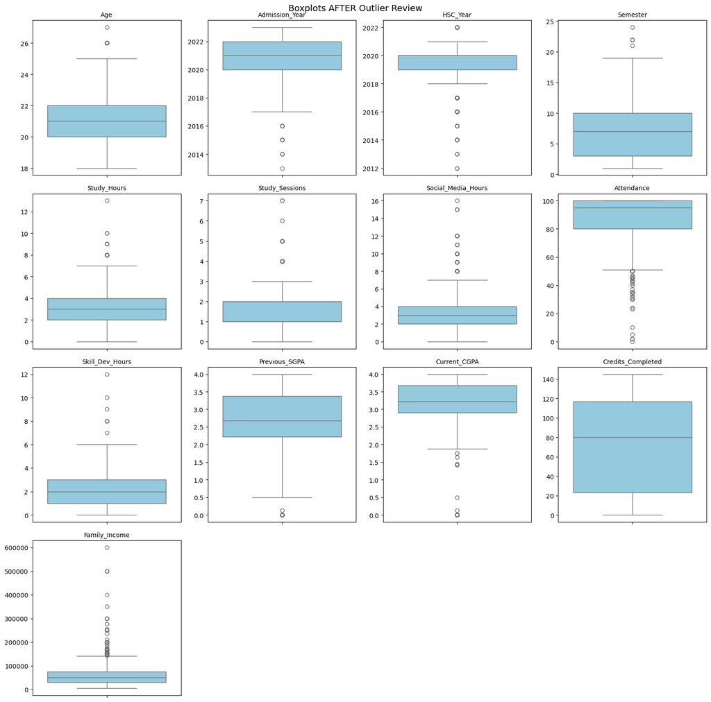

```python
plot_boxplots(df, numeric_cols, "Boxplots AFTER Outlier Review", "boxplots_after.jpg")
```

Comparing the two figures: every variable looks essentially the same before and after, since only two rows were removed in total, given that almost all the flagged points were genuine bulk clusters, not errors. The visible (subtle) changes are in the Social_Media_Hours panel, where the single point at 20 is gone, and the Family_Income panel, where the single point at 2,000,000 is gone.

### Additional Diagnostic Plots (Scatter Plots & Q-Q Plots)

Scatter plots help visually check the relationship between CGPA and other continuous variables, and Q-Q plots check how far each numeric variable departs from a normal distribution, which is relevant context for discussing distributional assumptions.

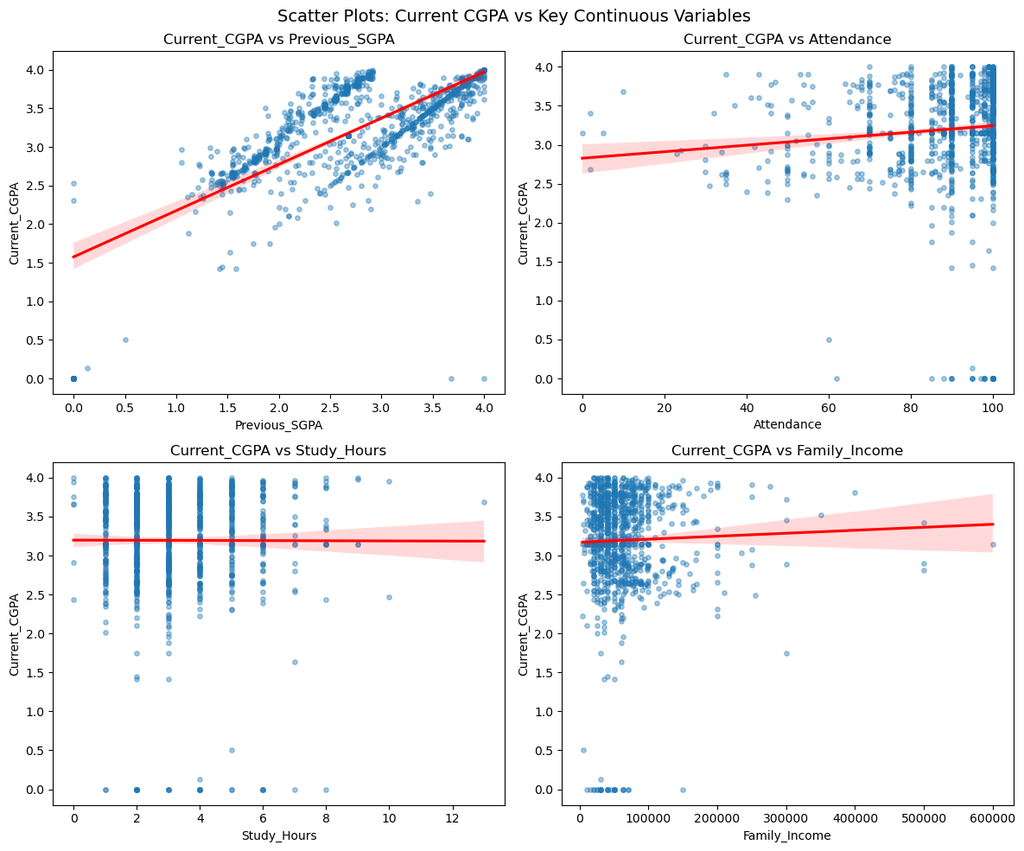

```python
# Scatter plots: Current_CGPA against other continuous variables
scatter_pairs = ["Previous_SGPA", "Attendance", "Study_Hours", "Family_Income"]

fig, axes = plt.subplots(2, 2, figsize=(12, 10))
axes = axes.flatten()
for i, col in enumerate(scatter_pairs):
    sns.regplot(x=df[col], y=df["Current_CGPA"], ax=axes[i],
                scatter_kws={"alpha": 0.4, "s": 15}, line_kws={"color": "red"})
    axes[i].set_title(f"Current_CGPA vs {col}")
fig.suptitle("Scatter Plots: Current CGPA vs Key Continuous Variables", fontsize=14)
fig.tight_layout()
plt.savefig("scatterplots_cgpa.jpg", dpi=200, bbox_inches="tight")
plt.show()
```

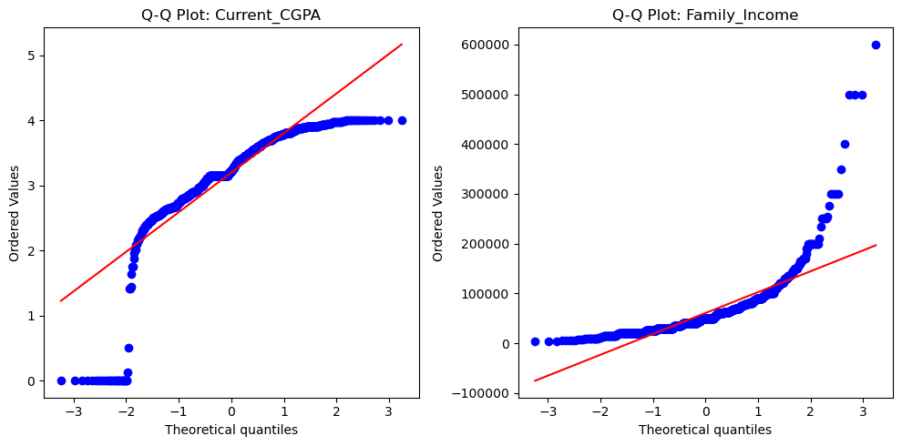

```python
# Q-Q plots: check normality of the two most relevant continuous variables
fig, axes = plt.subplots(1, 2, figsize=(10, 5))
stats.probplot(df["Current_CGPA"], dist="norm", plot=axes[0])
axes[0].set_title("Q-Q Plot: Current_CGPA")
stats.probplot(df["Family_Income"], dist="norm", plot=axes[1])
axes[1].set_title("Q-Q Plot: Family_Income")
fig.tight_layout()
plt.savefig("qqplots.jpg", dpi=200, bbox_inches="tight")
plt.show()
```

Both Q-Q plots show clear departures from the straight reference line, especially Family_Income (heavily right-skewed, as expected for income data)

## Step 3: Descriptive Statistics

```python
# Numeric variables: standard descriptive statistics
df[numeric_cols].describe().T
```

|  | count | mean | std | min | 25% | 50% | 75% | max |
| --- | --- | --- | --- | --- | --- | --- | --- | --- |
| Age | 1166.0 | 21.361063 | 1.617233 | 18.0 | 20.00 | 21.00 | 22.00 | 27.0 |
| Admission_Year | 1166.0 | 2020.500858 | 1.355801 | 2013.0 | 2020.00 | 2021.00 | 2022.00 | 2023.0 |
| HSC_Year | 1166.0 | 2019.199828 | 1.361153 | 2012.0 | 2019.00 | 2020.00 | 2020.00 | 2022.0 |
| Semester | 1166.0 | 6.607204 | 3.794518 | 1.0 | 3.00 | 7.00 | 10.00 | 24.0 |
| Study_Hours | 1166.0 | 3.158662 | 1.651543 | 0.0 | 2.00 | 3.00 | 4.00 | 13.0 |
| Study_Sessions | 1166.0 | 1.948542 | 0.859640 | 0.0 | 1.00 | 2.00 | 2.00 | 7.0 |
| Social_Media_Hours | 1166.0 | 3.280446 | 2.233820 | 0.0 | 2.00 | 3.00 | 4.00 | 16.0 |
| Attendance | 1166.0 | 88.263293 | 15.376259 | 0.0 | 80.25 | 95.00 | 100.00 | 100.0 |
| Skill_Dev_Hours | 1166.0 | 2.214408 | 1.289907 | 0.0 | 1.00 | 2.00 | 3.00 | 12.0 |
| Previous_SGPA | 1166.0 | 2.703560 | 0.837125 | 0.0 | 2.22 | 2.68 | 3.38 | 4.0 |
| Current_CGPA | 1166.0 | 3.194928 | 0.690494 | 0.0 | 2.91 | 3.22 | 3.68 | 4.0 |
| Credits_Completed | 1166.0 | 72.768439 | 47.842817 | 0.0 | 23.00 | 80.00 | 117.00 | 145.0 |
| Family_Income | 1166.0 | 60755.430532 | 50985.659280 | 4000.0 | 30000.00 | 50000.00 | 75000.00 | 600000.0 |

```python
categorical_cols = [
    "Gender", "Scholarship", "Uses_Transport", "Learning_Mode", "Uses_Smartphone", "Has_Computer",
    "English_Level", "Probation", "Suspension", "Teacher_Consultation", "Skills", "Interest_Area",
    "Relationship_Status", "Co_Curricular", "Living_With", "Health_Issues", "Physical_Disability",
]

# Categorical variables: mode (most common category) and how dominant it is
summary_rows = []
for col in categorical_cols:
    counts = df[col].value_counts()
    summary_rows.append({
        "Variable": col,
        "Mode (most common)": counts.index[0],
        "Count": counts.iloc[0],
        "% of sample": round(100 * counts.iloc[0] / len(df), 1),
    })
pd.DataFrame(summary_rows)
```

|  | Variable | Mode (most common) | Count | % of sample |
| --- | --- | --- | --- | --- |
| 0 | Gender | Male | 657 | 56.3 |
| 1 | Scholarship | No | 659 | 56.5 |
| 2 | Uses_Transport | No | 682 | 58.5 |
| 3 | Learning_Mode | Offline | 840 | 72.0 |
| 4 | Uses_Smartphone | Yes | 1152 | 98.8 |
| 5 | Has_Computer | Yes | 1070 | 91.8 |
| 6 | English_Level | Intermediate | 657 | 56.3 |
| 7 | Probation | No | 873 | 74.9 |
| 8 | Suspension | No | 1122 | 96.2 |
| 9 | Teacher_Consultation | Yes | 644 | 55.2 |
| 10 | Skills | Programming | 532 | 45.6 |
| 11 | Interest_Area | Software | 631 | 54.1 |
| 12 | Relationship_Status | Single | 874 | 75.0 |
| 13 | Co_Curricular | No | 672 | 57.6 |
| 14 | Living_With | Family | 622 | 53.3 |
| 15 | Health_Issues | No | 963 | 82.6 |
| 16 | Physical_Disability | No | 1141 | 97.9 |

## Step 4: Frequency Tables

```python
for col in categorical_cols + ["CGPA_Class"]:
    print(f"--- {col} ---")
    print(df[col].value_counts())
    print()
```

```
--- Gender ---
Gender
Male      657
Female    509
Name: count, dtype: int64

--- Scholarship ---
Scholarship
No     659
Yes    507
Name: count, dtype: int64

--- Uses_Transport ---
Uses_Transport
No     682
Yes    484
Name: count, dtype: int64

--- Learning_Mode ---
Learning_Mode
Offline    840
Online     326
Name: count, dtype: int64

--- Uses_Smartphone ---
Uses_Smartphone
Yes    1152
No       14
Name: count, dtype: int64

--- Has_Computer ---
Has_Computer
Yes    1070
No       96
Name: count, dtype: int64

--- English_Level ---
English_Level
Intermediate    657
Basic           292
```

[output cut: 69 more lines]

```
Name: count, dtype: int64

--- Physical_Disability ---
Physical_Disability
No     1141
Yes      25
Name: count, dtype: int64

--- CGPA_Class ---
CGPA_Class
General      334
2nd Lower    279
1st Class    278
2nd Upper    275
Name: count, dtype: int64
```

## Step 5: Graphs

A few variables (`Age`, `Admission_Year`, `HSC_Year`, `Study_Hours`, `Study_Sessions`, `Social_Media_Hours`, `Skill_Dev_Hours`) only take whole-number values spread across a small range. With histogram’s default automatic bin width, bins can land between two integers and pick up no observations, showing as a gap between bars even though the variable itself is fine. These columns are plotted with one bin per integer value below so the bars sit flush against each other; the remaining, genuinely continuous variables keep the default automatic binning.

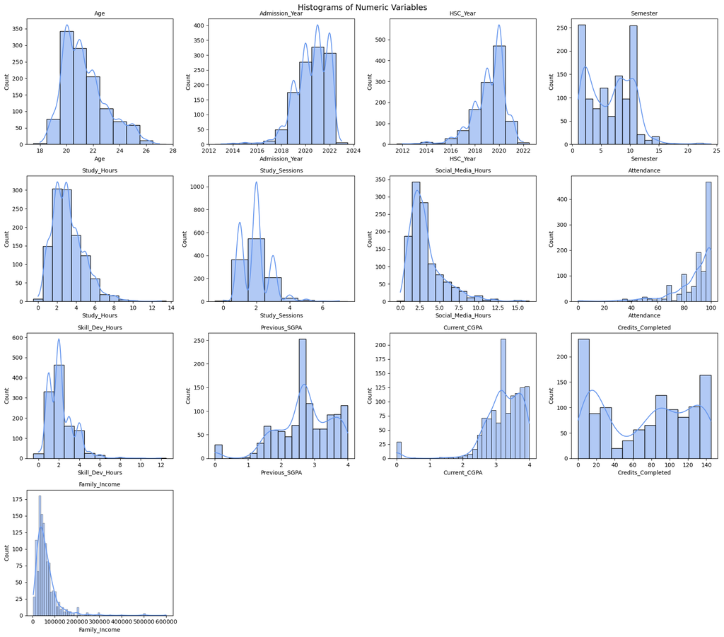

```python
# Histograms for all numeric variables
# Discrete count-type variables get one bin per integer value (discrete=True) so bars are
# contiguous with no gaps; the remaining continuous variables use automatic binning as before.
discrete_cols = {
    "Age", "Admission_Year", "HSC_Year", "Study_Hours", "Study_Sessions",
    "Social_Media_Hours", "Skill_Dev_Hours",
}

fig, axes = plt.subplots(4, 4, figsize=(18, 16))
axes = axes.flatten()
for i, col in enumerate(numeric_cols):
    sns.histplot(df[col], ax=axes[i], kde=True, color="cornflowerblue", discrete=(col in discrete_cols))
    axes[i].set_title(col, fontsize=10)
for j in range(len(numeric_cols), len(axes)):
    fig.delaxes(axes[j])
fig.suptitle("Histograms of Numeric Variables", fontsize=14)
fig.tight_layout()
plt.savefig("histograms_numeric.jpg", dpi=200, bbox_inches="tight")
plt.show()
```

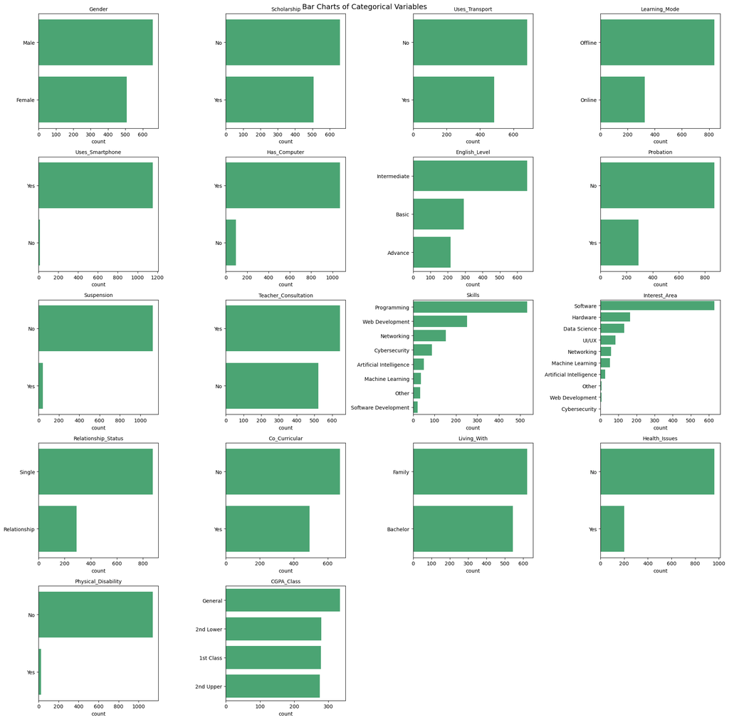

```python
# Bar charts for all categorical variables (incl. the outcome variable)
bar_cols = categorical_cols + ["CGPA_Class"]
fig, axes = plt.subplots(5, 4, figsize=(20, 20))
axes = axes.flatten()
for i, col in enumerate(bar_cols):
    order = df[col].value_counts().index
    sns.countplot(y=df[col], order=order, ax=axes[i], color="mediumseagreen")
    axes[i].set_title(col, fontsize=10)
    axes[i].set_ylabel("")
for j in range(len(bar_cols), len(axes)):
    fig.delaxes(axes[j])
fig.suptitle("Bar Charts of Categorical Variables", fontsize=14)
fig.tight_layout()
plt.savefig("barcharts_categorical.jpg", dpi=200, bbox_inches="tight")
plt.show()
```

## Step 6: Association Tests

- **Categorical predictors vs. CGPA_Class:** Chi-square test of independence.
- **Continuous predictors vs. CGPA_Class:** Kruskal-Wallis test (a non-parametric alternative to ANOVA seems appropriate here since CGPA_Class is ordinal and several continuous variables are skewed, as seen in the Q-Q plots above).

**Caveat:** the chi-square test assumes expected cell counts of at least 5 in each cell. A few categorical variables here (e.g. Skills, Interest_Area) have some sparse categories, so those specific results should be interpreted with some caution even though the test still runs.

```python
# Chi-square tests: each categorical variable vs CGPA_Class
chi2_results = []
for col in categorical_cols:
    contingency = pd.crosstab(df[col], df["CGPA_Class"])
    chi2, p, dof, expected = stats.chi2_contingency(contingency)
    chi2_results.append({"Variable": col, "Chi2": round(chi2, 3), "df": dof, "p-value": round(p, 4)})

chi2_df = pd.DataFrame(chi2_results).sort_values("p-value")
chi2_df["Significant (p<0.05)"] = chi2_df["p-value"] < 0.05
chi2_df
```

|  | Variable | Chi2 | df | p-value | Significant (p<0.05) |
| --- | --- | --- | --- | --- | --- |
| 1 | Scholarship | 65.152 | 3 | 0.0000 | True |
| 7 | Probation | 113.024 | 3 | 0.0000 | True |
| 6 | English_Level | 38.265 | 6 | 0.0000 | True |
| 11 | Interest_Area | 74.021 | 27 | 0.0000 | True |
| 10 | Skills | 57.224 | 21 | 0.0000 | True |
| 12 | Relationship_Status | 28.780 | 3 | 0.0000 | True |
| 8 | Suspension | 13.116 | 3 | 0.0044 | True |
| 9 | Teacher_Consultation | 10.929 | 3 | 0.0121 | True |
| 5 | Has_Computer | 9.228 | 3 | 0.0264 | True |
| 3 | Learning_Mode | 7.656 | 3 | 0.0537 | False |
| 13 | Co_Curricular | 7.386 | 3 | 0.0606 | False |
| 15 | Health_Issues | 7.102 | 3 | 0.0687 | False |
| 16 | Physical_Disability | 6.762 | 3 | 0.0799 | False |
| 14 | Living_With | 6.188 | 3 | 0.1028 | False |
| 0 | Gender | 5.188 | 3 | 0.1585 | False |
| 2 | Uses_Transport | 3.212 | 3 | 0.3601 | False |
| 4 | Uses_Smartphone | 1.143 | 3 | 0.7667 | False |

```python
# Kruskal-Wallis tests: each continuous variable vs CGPA_Class
# (Current_CGPA is excluded -- CGPA_Class is derived directly from it, so testing it against itself
#  would be circular)
continuous_predictors = [c for c in numeric_cols if c != "Current_CGPA"]

kw_results = []
for col in continuous_predictors:
    groups = [df.loc[df["CGPA_Class"] == cls, col].dropna() for cls in class_order]
    stat_val, p = stats.kruskal(*groups)
    kw_results.append({"Variable": col, "H-statistic": round(stat_val, 3), "p-value": round(p, 4)})

kw_df = pd.DataFrame(kw_results).sort_values("p-value")
kw_df["Significant (p<0.05)"] = kw_df["p-value"] < 0.05
kw_df
```

|  | Variable | H-statistic | p-value | Significant (p<0.05) |
| --- | --- | --- | --- | --- |
| 7 | Attendance | 63.117 | 0.0000 | True |
| 9 | Previous_SGPA | 470.597 | 0.0000 | True |
| 11 | Family_Income | 42.061 | 0.0000 | True |
| 2 | HSC_Year | 22.335 | 0.0001 | True |
| 6 | Social_Media_Hours | 18.609 | 0.0003 | True |
| 10 | Credits_Completed | 15.057 | 0.0018 | True |
| 1 | Admission_Year | 9.381 | 0.0246 | True |
| 0 | Age | 8.472 | 0.0372 | True |
| 3 | Semester | 6.535 | 0.0883 | False |
| 5 | Study_Sessions | 5.744 | 0.1248 | False |
| 8 | Skill_Dev_Hours | 4.813 | 0.1860 | False |
| 4 | Study_Hours | 2.221 | 0.5279 | False |

Variables with `Significant = True` show a statistically detectable association with CGPA class in this sample, and are good candidates to prioritize when you get to forward/backward selection for the ordinal logistic regression. A non-significant result here doesn't necessarily mean a variable is useless in the full model (interactions and confounding can change things), but it's a useful first-pass screen.

## Step 7: Export Outlier-Reviewed Dataset

```python
OUTPUT_PATH_XLSX = "Students_Performance_OUTLIER_CHECKED.xlsx"
OUTPUT_PATH_CSV = "Students_Performance_OUTLIER_CHECKED.csv"

df.to_excel(OUTPUT_PATH_XLSX, index=False)
df.to_csv(OUTPUT_PATH_CSV, index=False)

print("Final shape:", df.shape)
print(f"Saved to:\n  {OUTPUT_PATH_XLSX}\n  {OUTPUT_PATH_CSV}")
```

```
Final shape: (1166, 31)
Saved to:
  Students_Performance_OUTLIER_CHECKED.xlsx
  Students_Performance_OUTLIER_CHECKED.csv
```

## Summary

| Step | Result |
| --- | --- |
| Outlier review | 2 rows removed (Social_Media_Hours = 20, and Family_Income = 2,000,000 — both isolated, extreme single points); all other flagged values were genuine bulk clusters and were retained |
| Descriptive statistics | Computed for all numeric and categorical variables |
| Frequency tables | Computed for all categorical variables and CGPA_Class |
| Graphs | Histograms, bar charts, scatter plots, and Q-Q plots generated and saved as .jpg |
| Association tests | Chi-square (categorical) and Kruskal-Wallis (continuous) run against CGPA_Class |
| Final dataset | Exported as .xlsx and .csv, ready for the ordinal logistic regression stage |

**Saved image files (in the working folder):** `boxplots_before.jpg`, `boxplots_after.jpg`, `scatterplots_cgpa.jpg`, `qqplots.jpg`, `histograms_numeric.jpg`, `barcharts_categorical.jpg`